# Comparison to RAR binding from Mahony et al., 2011

John Blischak

**Last updated:** 2015-10-22

**Code version:** 044491cd5df4302bbdcf97ec1313fa184fc31516

```r
library("knitr")
opts_chunk$set(fig.align = "center", fig.width = 10)
```

I wanted to intersect the differential expression results with data on the binding location of retinoic acid receptor isoforms (RARs) in mouse embryonic stem cells (mESCs). [Mahony et al., 2011](http://www.genomebiology.com/content/12/1/R2) treated mESCs for 8 hours with RA and profiled RAR binding with ChIP-seq. I downloaded their Additional file 6, or [Supplementary Table S2](http://www.genomebiology.com/content/supplementary/gb-2011-12-1-r2-s6.doc). The description is below. I had to manually convert it from a doc file to a tab-delimited text file.

> **Additional file 6:**

> **Supplementary Table S2.** List of 96 differentially expressed genes (> 2-fold, P < 0.01) between day 2 + 8 hours RA and day 2. Tick marks denote the presence of RAR binding sites within 20 kbp of a gene’s transcription start site in the presence or absence of RA.

## Setup

Load packages.

```r
library("biomaRt")
library("tidyr")
library("ggplot2")
library("cowplot")
theme_set(theme_bw(base_size = 12))
```

Import the DE results.

```r
de_results <- read.table("../../data/mouse/de-results.txt",
                         header = TRUE)
head(de_results)
```

```
##                          logFC   logCPM       PValue          FDR    de
## ENSMUSG00000033845 -0.13449462 7.535947 3.402753e-01 4.713826e-01 FALSE
## ENSMUSG00000025903 -0.27935785 6.625184 3.944787e-02 8.981354e-02 FALSE
## ENSMUSG00000033813 -0.28073406 5.271903 1.329561e-02 3.736042e-02  TRUE
## ENSMUSG00000002459  1.98438205 1.091352 8.360234e-09 1.242997e-07  TRUE
## ENSMUSG00000033793  0.07886065 6.612570 4.574341e-01 5.857344e-01 FALSE
## ENSMUSG00000025907  0.39736543 6.682437 4.430506e-03 1.520137e-02  TRUE
```

Import [Supplementary Table S2](http://www.genomebiology.com/content/supplementary/gb-2011-12-1-r2-s6.doc) from [Mahony et al., 2011](http://www.genomebiology.com/content/12/1/R2).

```r
mahony <- read.table("../../data/mouse/mahony2011-table-s2.txt", sep = "\t",
                         header = TRUE, stringsAsFactors = FALSE)
colnames(mahony) <- c("probe", "fc", "pval", "woRA", "withRA")
mahony$woRA[is.na(mahony$woRA)] <- FALSE
mahony$withRA[is.na(mahony$withRA)] <- FALSE
stopifnot(length(unique(mahony$probe)) == nrow(mahony))
head(mahony)
```

```
##     probe    fc        pval  woRA withRA
## 1  Zfp703 7.985 0.000000841 FALSE  FALSE
## 2   Hoxb5 7.738 0.000000849 FALSE   TRUE
## 3   Hoxb1 7.569 0.000006550 FALSE   TRUE
## 4   Hoxb4 5.492 0.000036100 FALSE   TRUE
## 5 Cyp26a1 6.667 0.000111171  TRUE   TRUE
## 6   Hoxb2 4.070 0.000069000 FALSE   TRUE
```

Download Ensembl gene IDs.

```r
ensembl <- useMart(host = "sep2015.archive.ensembl.org",
                   biomart = "ENSEMBL_MART_ENSEMBL",
                   dataset = "mmusculus_gene_ensembl")
gene_info <- getBM(attributes = c("ensembl_gene_id", "chromosome_name",
                                  "external_gene_name"),
                      filter = c("external_gene_name", "chromosome_name"),
                      values = list(mahony$probe, c(1:19, "MT", "X", "Y")),
                      mart = ensembl)
stopifnot(length(unique(gene_info$external_gene_name)) == nrow(gene_info))
head(gene_info)
```

```
##      ensembl_gene_id chromosome_name external_gene_name
## 1 ENSMUSG00000041757               1            Plekha6
## 2 ENSMUSG00000058248               1              Kcnh1
## 3 ENSMUSG00000039485              10             Tspyl4
## 4 ENSMUSG00000001211              10             Agpat3
## 5 ENSMUSG00000033427              10               Upb1
## 6 ENSMUSG00000020052              10              Ascl1
```

83 of the 96 gene names were successfully converted to Ensembl gene IDs.

Merge the gene IDs.

```r
d <- merge(mahony, gene_info, by.x = "probe", by.y = "external_gene_name")
```

Merge the DE results.

```r
d <- merge(d, de_results, by.x = "ensembl_gene_id", by.y = "row.names")
```

67 of the 83 genes with Ensembl gene IDs are robustly expressed in this data set.

Classify the RA binding.

```r
ra_binding <- character(length = nrow(d))
for (i in 1:length(ra_binding)) {
  if (d$woRA[i] & d$withRA[i]) {
    ra_binding[i] <- "both"
  } else if (d$woRA[i] & !d$withRA[i]) {
    ra_binding[i] <- "-RA"
  } else if (!d$woRA[i] & d$withRA[i]) {
    ra_binding[i] <- "+RA"
  } else {
    ra_binding[i] <- "neither"
  }
}
table(ra_binding)
```

```
## ra_binding
##    both neither     -RA     +RA
##      16      40       1      10
```

Since there is only one observation of a pre-binding site that overlaps, remove it.

```r
d$ra_binding <- ra_binding
d <- d[d$ra_binding != "-RA", ]
d$ra_binding <- factor(d$ra_binding, levels = c("neither", "+RA", "both"))
```

Compare the results of the current study to those of [Mahony et al., 2011](http://www.genomebiology.com/content/12/1/R2). This analysis includes 66 genes.

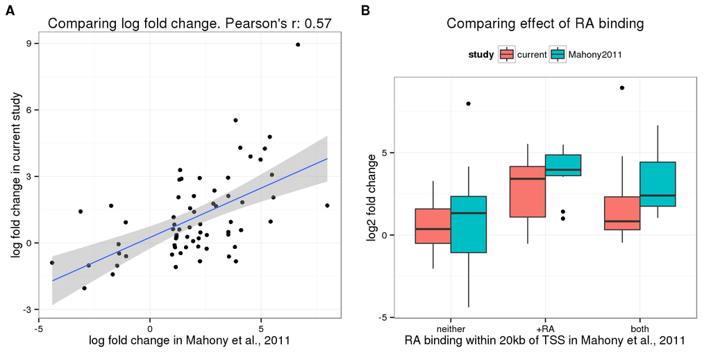

```r
compare_fc <- ggplot(d, aes(x = fc, y = logFC)) +
  geom_point() +
  geom_smooth(method = "lm") +
  labs(x = "log fold change in Mahony et al., 2011",
       y = "log fold change in current study",
       title = sprintf("Comparing log fold change. Pearson's r: %.2f",
                       cor(d$fc, d$logFC)))
d_long <- gather(d, key = "study", value = "logFC", fc, logFC)
d_long$study <- ifelse(d_long$study == "logFC", "current", "Mahony2011")
plot_ra_binding <- ggplot(d_long, aes(x = ra_binding, y = logFC)) +
  geom_boxplot(aes(fill = study)) +
  theme(legend.position = "top") +
  labs(x = "RA binding within 20kb of TSS in Mahony et al., 2011",
       y = "log2 fold change",
       title = "Comparing effect of RA binding")
plot_grid(compare_fc, plot_ra_binding, labels = LETTERS[1:2])
```

Reassuringly, the log fold change estimates are modestly correlated between the two studies. The RAR binding results are more difficult to interpret, especially since there is only one observation available of a RAR bound location only in the absence of RA. However, consistent with the known activating role of ligand-bound RARs, on average the largest log fold changes observed in both studies are for the genes bound by RAR only in the presence of ligand.